# Homework Assignment #1: Data, Descriptives, & Basic Regression

EDUC/PSY 7610: Regression Analysis

Instructor: Jamison Fargo, PhD

February 13, 2023

Please complete the following exercises. You must include the code (as brief as possible) that was used to run each exercise along with the results. You may work in groups of 2 or 3 if you like, but each student should submit their own homework assignment. You will be able to upload your completed assignment to CANVAS. You may complete these exercises using BlueSky or R Studio (eg, script or R Markdown).

### Part I: Visualizing Data

1. Using any method for displaying univariate distributions of data, examine the distributions of the indicated variables from the following data sets (all from the `carData` package) and add a brief figure caption below each figure. In each case, examine data for skewness, non-normality, multiple modes, and unusual values and report or describe what what you observe:  
   1.1. `Angell`: `moral` integration, ethnic `hetero`geneity, geographic `mobility`.  
   1.2. `Prestige`: `prestige`, `income`, `education`.  
   1.3. `Leinhardt`: `income`, (infant) `mortality`.

### Exercise 1: Findings of the above problem and the graphs are shown below:

*1.1. Variable: moral integration*

**skewness**: -0.01912821. A skewness value of -0.01912821 means that the data is slightly left-skewed.

**non-normality**: From Shapiro-Wilk normality test, p-value = 0.8263. So, the distribution is normal.

**multiple modes**: From Hartigans’ dip test, p-value = 0.8658. So, the distribution is unimodal.

**Unusual values**: From the boxplot, it can be seen that there are no unusual values.

*Variable: ethnic hetero geneity*

**skewness**: 1.226228. A skewness value of 1.226228 indicates that a data set is positively skewed.

**non-normality**: From Shapiro-Wilk normality test, p-value = 2.563e-05. So, the distribution is not normal.

**multiple modes**: From Hartigans’ dip test, p-value = 0.9922. So, the distribution is unimodal.

**Unusual values**: From the boxplot, it can be seen that there are three unusual values.

*Variable: geographic mobility*

**skewness**: 0.4120319. A skewness value of 0.4120319 indicates that a data set is positively skewed, but to a lesser extent.

**non-normality**: From Shapiro-Wilk normality test, p-value = 0.1915. So, the distribution is normal.

**multiple modes**: From Hartigans’ dip test, p-value = 0.7713.So, the distribution is unimodal.

**Unusual values**: From the boxplot, it can be seen that there are no unusual values.

*1.2 Variable: prestige*

**skewness**: 0.3335949. A skewness value of 0.3335949 indicates that a data set is positively skewed, but to a lesser extent.

**non-normality**: From Shapiro-Wilk normality test, p-value = 0.02875. So, the distribution is not normal.

**multiple modes**: From Hartigans’ dip test, p-value = 0.9878.So, the distribution is unimodal.

**Unusual values**: From the boxplot, it can be seen that there are no unusual values.

*Variable: income*

**skewness**: 2.160717. A skewness value of 2.160717 indicates that a data set is strongly positively skewed.

**non-normality**: From Shapiro-Wilk normality test, p-value = 5.634e-10. So, the distribution is not normal.

**multiple modes**: From Hartigans’ dip test, p-value = 0.9587.So, the distribution is unimodal.

**Unusual values**: From the boxplot, it can be seen that there are five unusual values.

*Variable: education*

**skewness**: 0.3295856. A skewness value of 0.3295856 indicates that a data set is positively skewed, but to a lesser extent.

**non-normality**: From Shapiro-Wilk normality test, p-value = 0.0006773. So, the distribution is not normal.

**multiple modes**: From Hartigans’ dip test, p-value = 0.5842.So, the distribution is unimodal.

**Unusual values**: From the boxplot, it can be seen that there are no unusual values.

*1.3 Variable: income*

**skewness**: 1.778722. A skewness value of 1.778722 indicates that a data set is positively skewed.

**non-normality**: From Shapiro-Wilk normality test, p-value = 8.129e-14. So, the distribution is not normal.

**multiple modes**: From Hartigans’ dip test, p-value = 0.9614.So, the distribution is unimodal.

**Unusual values**: From the boxplot, it can be seen that there are more than 10 unusual values.

*Variable: infant mortality*

**skewness**: 2.96403. A skewness value of 2.96403 indicates that a data set is strongly positively skewed.

**non-normality**: From Shapiro-Wilk normality test, p-value = 3.157e-12. So, the distribution is not normal.

**multiple modes**: From Hartigans’ dip test, p-value = 0.9162.So, the distribution is unimodal.

**Unusual values**: From the boxplot, it can be seen that there are three unusual values.

```r
library(carData)
library(car)
library(tidyverse)
library(jtools)
library(gtsummary)
library(broom)
library(PerformanceAnalytics)
```

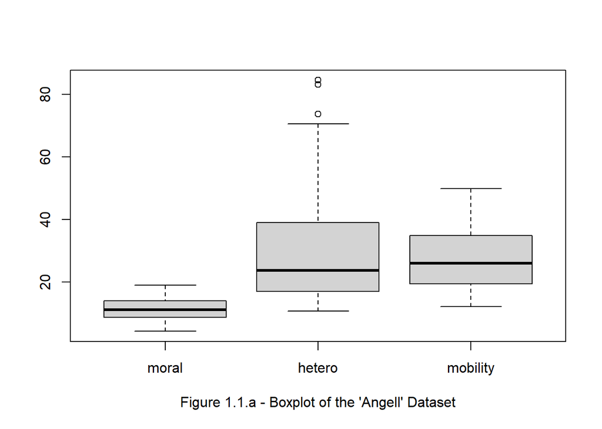

```r
library(ggplot2)
library(diptest)

boxplot(as.data.frame(Angell[1:3]))
mtext("Figure 1.1.a - Boxplot of the 'Angell' Dataset",side=1,line=3)
```

```r
shapiro.test(Angell$moral)
```

```
##
##  Shapiro-Wilk normality test
##
## data:  Angell$moral
## W = 0.98466, p-value = 0.8263
```

```r
skewness(Angell$moral)
```

```
## [1] -0.01912821
```

```r
dip.test(Angell$moral)
```

```
##
##  Hartigans' dip test for unimodality / multimodality
##
## data:  Angell$moral
## D = 0.041528, p-value = 0.8658
## alternative hypothesis: non-unimodal, i.e., at least bimodal
```

```r
shapiro.test(Angell$hetero)
```

```
##
##  Shapiro-Wilk normality test
##
## data:  Angell$hetero
## W = 0.83746, p-value = 2.563e-05
```

```r
skewness(Angell$hetero)
```

```
## [1] 1.226228
```

```r
dip.test(Angell$hetero)
```

```
##
##  Hartigans' dip test for unimodality / multimodality
##
## data:  Angell$hetero
## D = 0.03125, p-value = 0.9922
## alternative hypothesis: non-unimodal, i.e., at least bimodal
```

```r
shapiro.test(Angell$mobility)
```

```
##
##  Shapiro-Wilk normality test
##
## data:  Angell$mobility
## W = 0.96385, p-value = 0.1915
```

```r
skewness(Angell$mobility)
```

```
## [1] 0.4120319
```

```r
dip.test(Angell$mobility)
```

```
##
##  Hartigans' dip test for unimodality / multimodality
##
## data:  Angell$mobility
## D = 0.044723, p-value = 0.7713
## alternative hypothesis: non-unimodal, i.e., at least bimodal
```

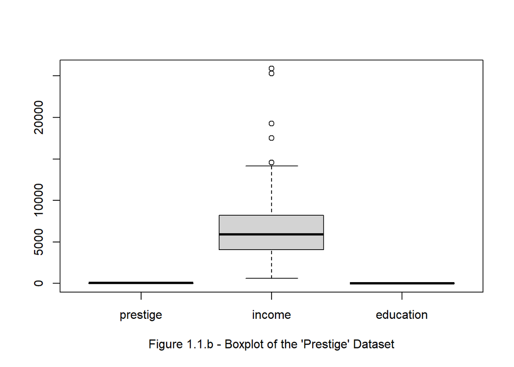

```r
boxplot(as.data.frame(Prestige[c(4,2,1)]))
mtext("Figure 1.1.b - Boxplot of the 'Prestige' Dataset",side=1,line=3)
```

```r
shapiro.test(Prestige$prestige)
```

```
##
##  Shapiro-Wilk normality test
##
## data:  Prestige$prestige
## W = 0.97198, p-value = 0.02875
```

```r
skewness(Prestige$prestige)
```

```
## [1] 0.3335949
```

```r
dip.test(Prestige$prestige)
```

```
##
##  Hartigans' dip test for unimodality / multimodality
##
## data:  Prestige$prestige
## D = 0.022848, p-value = 0.9878
## alternative hypothesis: non-unimodal, i.e., at least bimodal
```

```r
shapiro.test(Prestige$income)
```

```
##
##  Shapiro-Wilk normality test
##
## data:  Prestige$income
## W = 0.81505, p-value = 5.634e-10
```

```r
skewness(Prestige$income)
```

```
## [1] 2.160717
```

```r
dip.test(Prestige$income)
```

```
##
##  Hartigans' dip test for unimodality / multimodality
##
## data:  Prestige$income
## D = 0.024909, p-value = 0.9587
## alternative hypothesis: non-unimodal, i.e., at least bimodal
```

```r
shapiro.test(Prestige$education)
```

```
##
##  Shapiro-Wilk normality test
##
## data:  Prestige$education
## W = 0.94958, p-value = 0.0006773
```

```r
skewness(Prestige$education)
```

```
## [1] 0.3295856
```

```r
dip.test(Prestige$education)
```

```
##
##  Hartigans' dip test for unimodality / multimodality
##
## data:  Prestige$education
## D = 0.033581, p-value = 0.5842
## alternative hypothesis: non-unimodal, i.e., at least bimodal
```

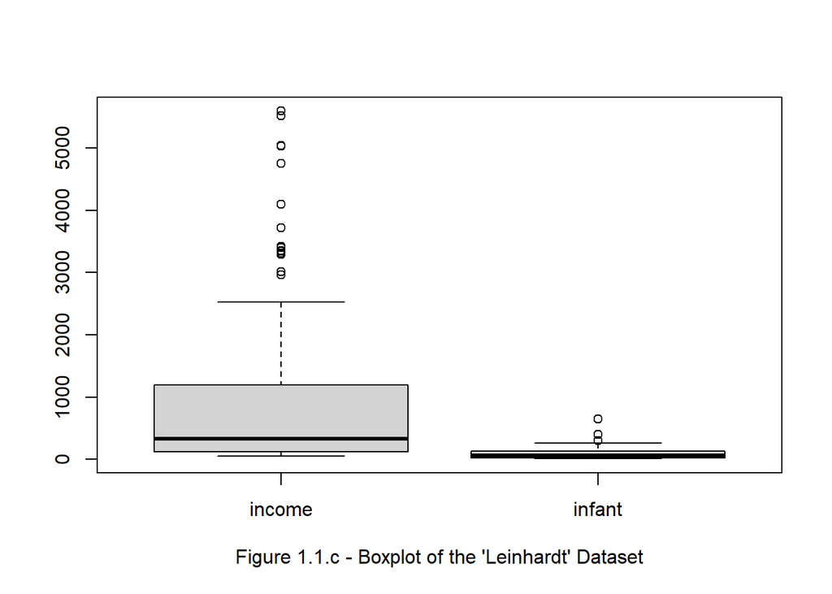

```r
boxplot(as.data.frame(Leinhardt[1:2]))
mtext("Figure 1.1.c - Boxplot of the 'Leinhardt' Dataset",side=1,line=3)
```

```r
shapiro.test(Leinhardt$income)
```

```
##
##  Shapiro-Wilk normality test
##
## data:  Leinhardt$income
## W = 0.67956, p-value = 8.129e-14
```

```r
skewness(Leinhardt$income)
```

```
## [1] 1.778722
```

```r
dip.test(Leinhardt$income)
```

```
##
##  Hartigans' dip test for unimodality / multimodality
##
## data:  Leinhardt$income
## D = 0.024409, p-value = 0.9614
## alternative hypothesis: non-unimodal, i.e., at least bimodal
```

```r
shapiro.test(Leinhardt$infant)
```

```
##
##  Shapiro-Wilk normality test
##
## data:  Leinhardt$infant
## W = 0.73436, p-value = 3.157e-12
```

```r
skewness(Leinhardt$infant)
```

```
## [1] 2.96403
```

```r
dip.test(Leinhardt$infant)
```

```
##
##  Hartigans' dip test for unimodality / multimodality
##
## data:  Leinhardt$infant
## D = 0.026706, p-value = 0.9162
## alternative hypothesis: non-unimodal, i.e., at least bimodal
```

2. Construct parallel boxplots for each of the following data set and pairs of variables and add a brief figure caption below each figure. In each case, examine data for skewness, non-normality, multiple modes, and unusual values and report or describe what what you observe:  
   2.1. `Angell`: `moral` integration by `region`.  
   2.2. `Prestige`: `prestige` by `type`.  
   2.3. `Leinhardt`: `infant` mortality by `region`.

### Exercise 2: Findings of the above problem and the graphs are shown below:

*2.1 Variable: `moral` integration by `region`*

**skewness**: 1. E=0.0138, 2. MW=-0.479, 3. S=-0.270, 4. W= 0.0886; Skewness value E=0.0138 and W= 0.0886 indicate that they are almost not skewed. Skewness value MW=-0.47 and S=-0.270 indicate that they are slightly negatively skewed.

**non-normality**: From Shapiro-Wilk normality test, 1. E=0.9820727, 2. MW= 0.5665098, 3. S=0.1469088, 4. W=0.9725267. All of them are more than 5%. So, their distribution are normal.

**multiple modes**: As there are not more than one peak or central location in the box plots, so all of them are unimodal.

**Unusual values**: From the boxplot, it can be seen that there are no unusual values.

*2.2 Variable: `prestige` by `type`*

**skewness**: 1. bc=0.0547, 2. prof=0.374, 3. wc=0.676, 4. NA= -0.0348; Skewness value bc=0.0547 and NA= -0.0348 indicate that they are almost not skewed. Skewness value prof=0.374 and wc=0.676 indicate that they are slightly positively skewed.

**non-normality**: From Shapiro-Wilk normality test, 1. bc=0.2426787, 2. prof= 0.5404199, 3. wc=0.5508259. All of them are more than 5%. So, their distribution are normal.

**multiple modes**: As there are not more than one peak or central location in the box plots, so all of them are unimodal.

*2.3 Variable: `infant` mortality by `region`*

**skewness**: 1. Africa=0.649, 2. Americas=2.13, 3. Asia=2.92, 4. Europe=1.46; Skewness value, Africa=0.649 indicates that this is slightly positively skewed. Skewness values, Americas=2.13, Asia=2.92 and Europe=1.46 indicate that they are strongly positively skewed.

**multiple modes**: As there are not more than one peak or central location in the box plots, so all of them are unimodal.

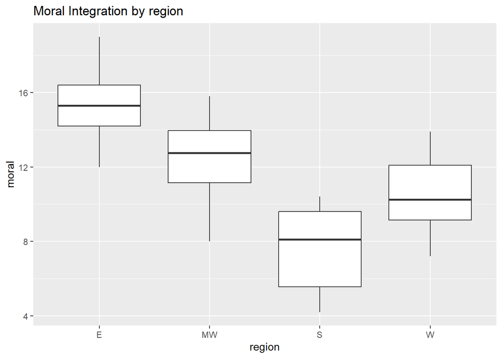

```r
p1<-ggplot(Angell, aes(x=region, y=moral, fill= moral))+
  geom_boxplot(show.legend = FALSE, outlier.shape = NA)
p1 + ggtitle("Moral Integration by region")
```

```r
grouped_data1 <- split(Angell$moral, Angell$region)
results1 <- lapply(grouped_data1, shapiro.test)
p_values1 <- sapply(results1, function(x) x$p.value)
p_values1
```

```
##         E        MW         S         W
## 0.9820727 0.5665098 0.1469088 0.9725267
```

```r
skewness_by_group1<-Angell%>%
  group_by(region) %>%
  summarize(skewness = skewness(moral))
skewness_by_group1
```

```
## # A tibble: 4 × 2
##   region skewness
##   <fct>     <dbl>
## 1 E        0.0138
## 2 MW      -0.479
## 3 S       -0.270
## 4 W        0.0886
```

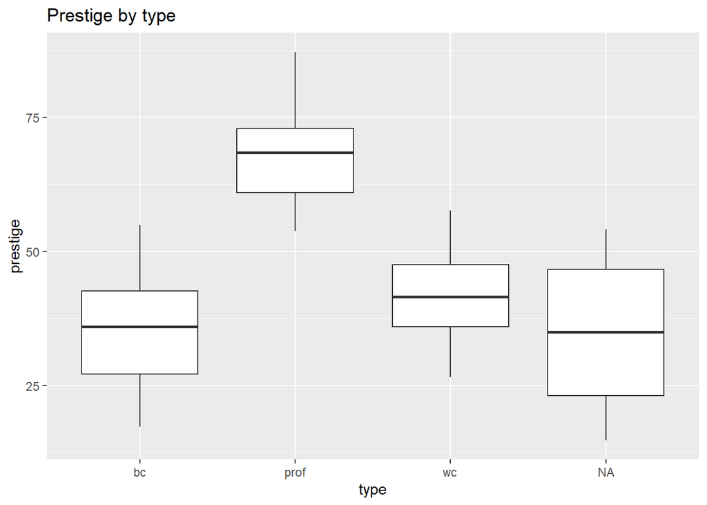

```r
p2<-ggplot(Prestige, aes(x=type, y=prestige, fill= prestige))+
  geom_boxplot(show.legend = FALSE, outlier.shape = NA)
p2 + ggtitle("Prestige by type")
```

```r
grouped_data2 <- split(Prestige$prestige, Prestige$type)
results2 <- lapply(grouped_data2, shapiro.test)
p_values2 <- sapply(results2, function(x) x$p.value)
p_values2
```

```
##        bc      prof        wc
## 0.2426787 0.5404199 0.5508259
```

```r
skewness_by_group2<-Prestige%>%
  group_by(type) %>%
  summarize(skewness = skewness(prestige))
skewness_by_group2
```

```
## # A tibble: 4 × 2
##   type  skewness
##   <fct>    <dbl>
## 1 bc      0.0547
## 2 prof    0.374
## 3 wc      0.676
## 4 <NA>   -0.0348
```

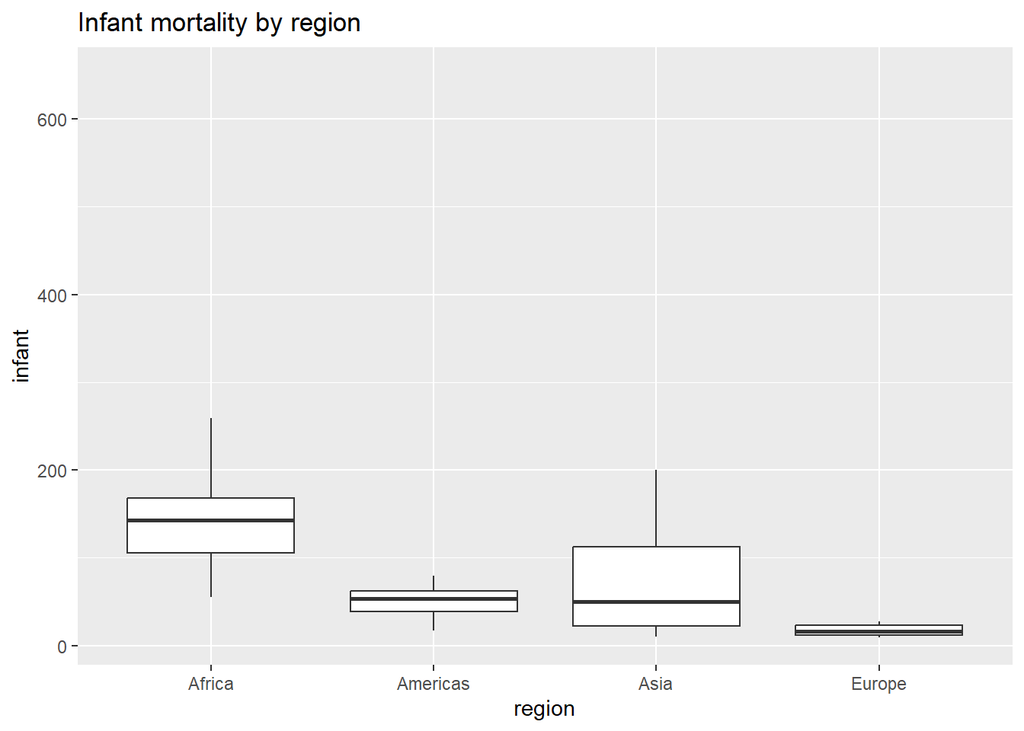

```r
p3<-ggplot(Leinhardt, aes(x=region, y=infant, fill= infant))+
  geom_boxplot(show.legend = FALSE, outlier.shape = NA)
p3 + ggtitle("Infant mortality by region")
```

```r
grouped_data3 <- split(Leinhardt$infant, Leinhardt$region)
results3 <- lapply(grouped_data3, shapiro.test)
p_values3 <- sapply(results3, function(x) x$p.value)
p_values3
```

```
##       Africa     Americas         Asia       Europe
## 2.258847e-01 3.503233e-04 1.992767e-07 1.329564e-03
```

```r
skewness_by_group3<-Leinhardt%>%
  group_by(region) %>%
  summarize(skewness = skewness(infant))
skewness_by_group3
```

```
## # A tibble: 4 × 2
##   region   skewness
##   <fct>       <dbl>
## 1 Africa      0.649
## 2 Americas    2.13
## 3 Asia        2.92
## 4 Europe      1.46
```

3. Construct a scatterplot matrix for each of the following data sets and variables, and add a brief figure caption below each figure. In each case, examine data for skewness, non-normality, multiple modes, and unusual values and report or describe what what you observe (eg, normality, linear relationship):  
   3.1. `Angell`: `moral` integration, ethnic `hetero`geneity, geographic `mobility`. Use a different plotting symbol or color for cities in different regions;  
   3.2. `Prestige`: `prestige`, `income`, `education`.  
   3.3. `Leinhardt`: `income`, (infant) `mortality`.

### Exercise 3: Findings of the above problem and the graphs are shown below:

*3.1 `Angell`: `moral` integration, ethnic `hetero`geneity, geographic `mobility`.*

**multiple modes**: From ggpair and ggplot graph, it can be seen that the distributions are unimodal.

*3.2 `Prestige`: `prestige`, `income`, `education`*

**skewness**: From ggpair and ggplot graph, income is positively skewed and prestige and education are slightly positively skewed.

**non-normality**: From Shapiro-Wilk normality test, p-value = 0.0006773. So, the distribution is not normal.

**multiple modes**: From ggpair and ggplot graph, it can be seen that the distributions are unimodal.

**Unusual values**: From the ggpair and ggplot, there are few unusual values are in the dataset (variables: prestige, income, education).

*3.3 `Leinhardt`: `income`, (infant) `mortality`.*

**skewness**: From ggpair and ggplot graph, income and infant mortality are strongly positively skewed.

**non-normality**: From Shapiro-Wilk normality test, p-value = 8.129e-14. So, the distribution is not normal.

**multiple modes**: From ggpair and ggplot graph, it can be seen that the distributions are unimodal.

**Unusual values**: From the ggpair and ggplot, there are few unusual values are in the dataset (variables: income and infant mortality).

```r
library(GGally)
```

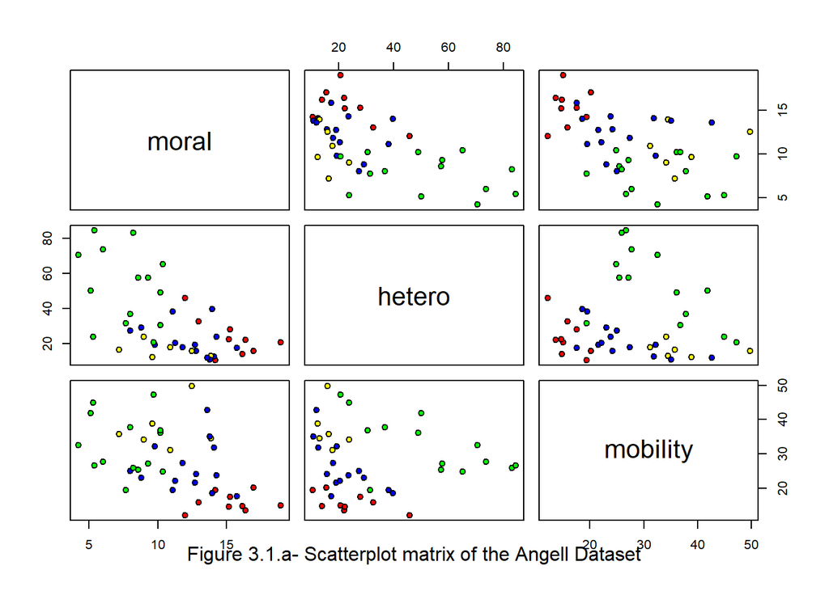

```r
colors<- c('red', 'blue', 'green', 'yellow')
pairs(Angell[1:3], pch=21, bg=colors[(Angell$region)])
mtext("Figure 3.1.a- Scatterplot matrix of the Angell Dataset",side=1,line=3)
```

```r
angell_col1 <- as.numeric(Angell[,1])
shapiro_test1 <- shapiro.test(angell_col1)
shapiro_test1
```

```
##
##  Shapiro-Wilk normality test
##
## data:  angell_col1
## W = 0.98466, p-value = 0.8263
```

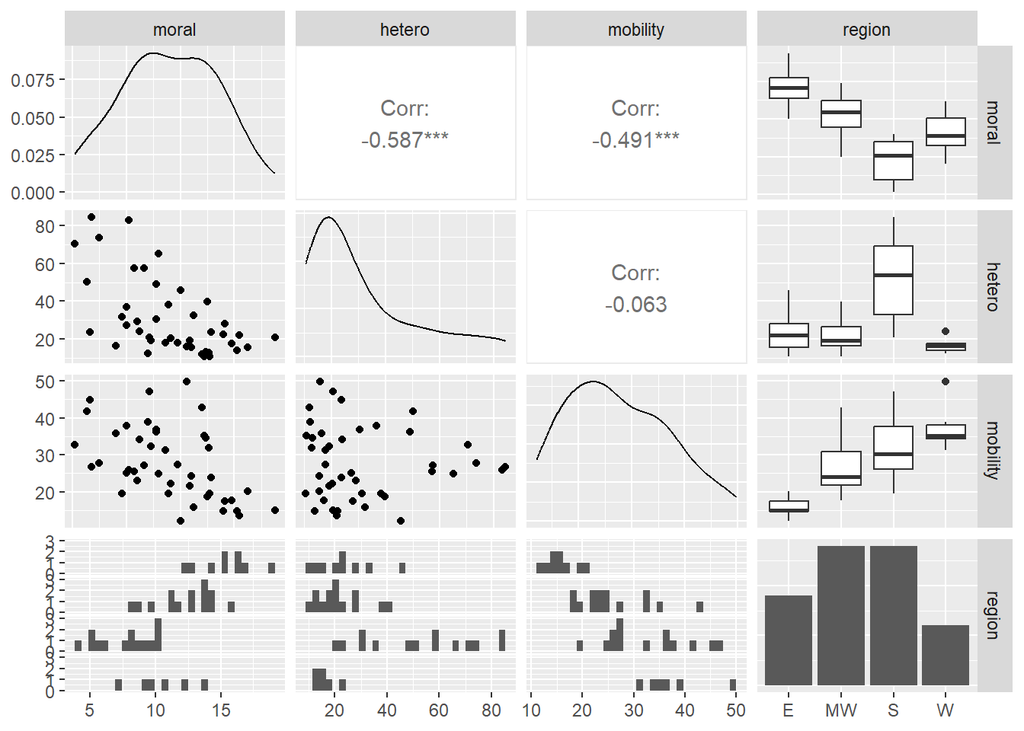

```r
ggpairs(Angell[, 1:4])
```

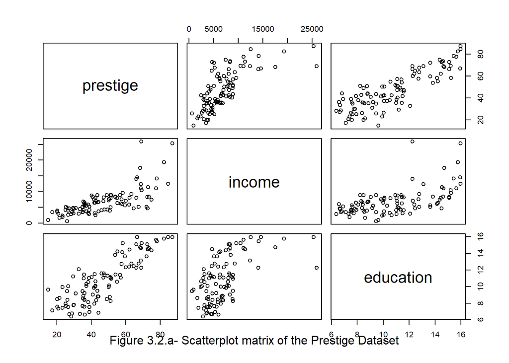

```r
pairs(Prestige[c(4,2,1)], pch=21)
mtext("Figure 3.2.a- Scatterplot matrix of the Prestige Dataset",side=1,line=3)
```

```r
angell_col2 <- as.numeric(Prestige[,1])
shapiro_test2 <- shapiro.test(angell_col2)
shapiro_test2
```

```
##
##  Shapiro-Wilk normality test
##
## data:  angell_col2
## W = 0.94958, p-value = 0.0006773
```

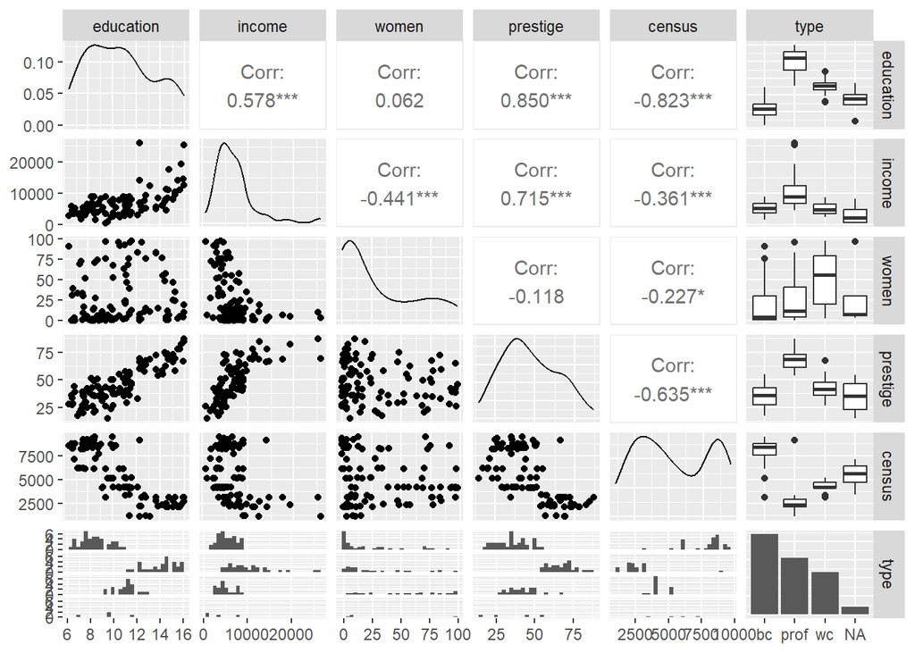

```r
ggpairs(Prestige[, 1:6])
```

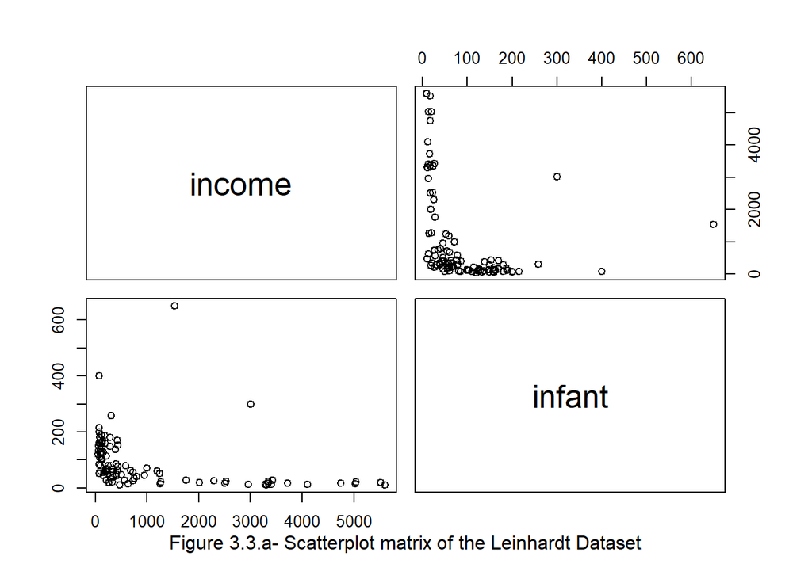

```r
pairs(Leinhardt[1:2], pch=21)
mtext("Figure 3.3.a- Scatterplot matrix of the Leinhardt Dataset",side=1,line=3)
```

```r
angell_col3 <- as.numeric(Leinhardt[,1])
shapiro_test3 <- shapiro.test(angell_col3)
shapiro_test3
```

```
##
##  Shapiro-Wilk normality test
##
## data:  angell_col3
## W = 0.67956, p-value = 8.129e-14
```

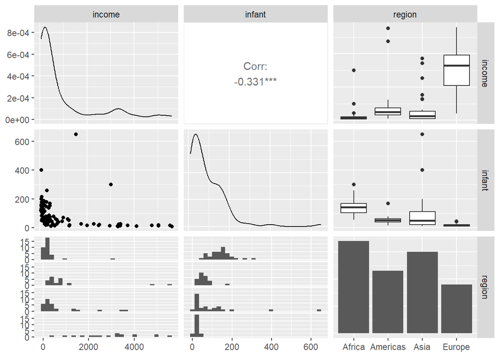

```r
ggpairs(Leinhardt[, 1:3])
```

### Part II: Descriptive Statistics

Create a table of descriptive statistics for each of the following data sets (all from the `carData` package) and specific variables:

1. `Angell`: `moral` integration, ethnic `hetero`geneity, geographic `mobility`
2. `Prestige`: `prestige`, `income`, `education`
3. `Leinhardt`: `income`, (infant) `mortality`

### Exercise Descriptive Statistics:

```r
library(pastecs)
```

```r
angell1<-stat.desc(Angell[1:3])
colnames(angell1)<- c("moral integration", "ethnic hetero geneity", "geographic mobility")
cat("\nDescriptive Summary of Angell dataset\n\n")
```

```
##
## Descriptive Summary of Angell dataset
```

```r
angell1
```

```
##              moral integration ethnic hetero geneity geographic mobility
## nbr.val             43.0000000            43.0000000          43.0000000
## nbr.null             0.0000000             0.0000000           0.0000000
## nbr.na               0.0000000             0.0000000           0.0000000
## min                  4.2000000            10.6000000          12.1000000
## max                 19.0000000            84.5000000          49.8000000
## range               14.8000000            73.9000000          37.7000000
## sum                481.6000000          1349.0000000        1186.7000000
## median              11.1000000            23.7000000          25.9000000
## mean                11.2000000            31.3720930          27.5976744
## SE.mean              0.5446915             3.1127223           1.4927825
## CI.mean.0.95         1.0992319             6.2817279           3.0125571
## var                 12.7576190           416.6287265          95.8211849
## std.dev              3.5717809            20.4114852           9.7888296
## coef.var             0.3189090             0.6506255           0.3546976
```

```r
Prestige1<- stat.desc(Prestige[c(4,2,1)])
colnames(Prestige1)<- c("prestige", "income", "education")
cat("\nDescriptive Summary of Prestige dataset\n\n")
```

```
##
## Descriptive Summary of Prestige dataset
```

```r
Prestige1
```

```
##                  prestige       income    education
## nbr.val       102.0000000 1.020000e+02  102.0000000
## nbr.null        0.0000000 0.000000e+00    0.0000000
## nbr.na          0.0000000 0.000000e+00    0.0000000
## min            14.8000000 6.110000e+02    6.3800000
## max            87.2000000 2.587900e+04   15.9700000
## range          72.4000000 2.526800e+04    9.5900000
## sum          4777.0000000 6.933860e+05 1095.2800000
## median         43.6000000 5.930500e+03   10.5400000
## mean           46.8333333 6.797902e+03   10.7380392
## SE.mean         1.7034979 4.204089e+02    0.2701562
## CI.mean.0.95    3.3792816 8.339783e+02    0.5359173
## var           295.9943234 1.802786e+07    7.4444080
## std.dev        17.2044856 4.245922e+03    2.7284442
## coef.var        0.3673556 6.245930e-01    0.2540915
```

```r
Leinhardt1<- stat.desc(Leinhardt[1:2])
colnames(Leinhardt1)<- c("income", "mortality")
cat("\nDescriptive Summary of Leinhardt dataset\n\n")
```

```
##
## Descriptive Summary of Leinhardt dataset
```

```r
Leinhardt1
```

```
##                    income   mortality
## nbr.val      1.050000e+02  101.000000
## nbr.null     0.000000e+00    0.000000
## nbr.na       0.000000e+00    4.000000
## min          5.000000e+01    9.600000
## max          5.596000e+03  650.000000
## range        5.546000e+03  640.400000
## sum          1.047970e+05 8993.800000
## median       3.340000e+02   60.600000
## mean         9.980667e+02   89.047525
## SE.mean      1.382572e+02    9.035107
## CI.mean.0.95 2.741691e+02   17.925396
## var          2.007079e+06 8244.949919
## std.dev      1.416714e+03   90.801707
## coef.var     1.419459e+00    1.019699
```

### Part III: Correlation

These exercises require the use of the `Prestige` data set from the `carData` package in R.

1. Compute and present a correlation matrix for the following variables: `prestige`, `education`, and `income`.
2. Interpret the coefficient for the relationship between `prestige` and `education` only (hint: square the correlation coefficient).
3. Interpret the partial correlation coefficient for the relationship between `prestige` (outcome) and `education` (predictor).
4. Interpret the semi-partial correlation coefficient for the relationship between `prestige` (outcome) and `education` (predictor).

### Exercise Correlation Analysis:

1. A correlation matrix for the following variables: `prestige`, `education`, and `income`

```r
var_of_interest1 <- Prestige[, c("prestige", "education", "income")]
cor_matrix1 <- cor(var_of_interest1)
cor_matrix1
```

```
##            prestige education    income
## prestige  1.0000000 0.8501769 0.7149057
## education 0.8501769 1.0000000 0.5775802
## income    0.7149057 0.5775802 1.0000000
```

2. The correlation coefficient of 0.8501769 suggests a strong positive relationship between prestige and education. This means that as the level of education increases, the level of prestige also tends to increase.

```r
var_of_interest2<- Prestige[, c("prestige", "education")]
cor_matrix2 <- cor(var_of_interest2)
cor_matrix2
```

```
##            prestige education
## prestige  1.0000000 0.8501769
## education 0.8501769 1.0000000
```

```r
library(ppcor)
var_of_interest3 <- Prestige[, c("prestige", "education")]
partial_cor_coeffs3 <- pcor(var_of_interest3)
partial_cor_coeffs3
```

```
## $estimate
##            prestige education
## prestige  1.0000000 0.8501769
## education 0.8501769 1.0000000
##
## $p.value
##               prestige    education
## prestige  0.000000e+00 1.286264e-29
## education 1.286264e-29 0.000000e+00
##
## $statistic
##           prestige education
## prestige    0.0000   16.1478
## education  16.1478    0.0000
##
## $n
## [1] 102
##
## $gp
## [1] 0
##
## $method
## [1] "pearson"
```

```r
var_of_interest4 <- spcor(Prestige[, c("prestige", "education")])$estimate
var_of_interest4
```

```
##            prestige education
## prestige  1.0000000 0.8501769
## education 0.8501769 1.0000000
```

### Part IV: Simple Regression

The `Seatbelts` dataset from the `datasets` package (automatically initiated with R) includes data on motor-vehicle mortality in the United Kingdom with and without a mandatory seatbelt use law in effect. Compute the following statistics between `DriversKilled` and `law` (0 = No law, 1 = law in effect):

1. Point-biserial correlation.
2. Independent-samples $t$-test (NOTE: law will first need to be recoded as a factor).
3. Simple regression of `DriversKilled` on `law` (`law` can either be a factor or numeric variable in this analysis).
4. Report on the results of each analysis and draw parallels among them.

### Exercise Simple Regression Analysis:

1. Point-biserial correlation:

```r
Seatbelts <- as.data.frame(Seatbelts)
Seatbelts$law_f <- factor(Seatbelts$law,
                        levels = c(0,1),
                        labels = c("No Law", "Law"))
cor.test( Seatbelts$DriversKilled,Seatbelts$law)
```

```
##
##  Pearson's product-moment correlation
##
## data:  Seatbelts$DriversKilled and Seatbelts$law
## t = -4.7942, df = 190, p-value = 3.288e-06
## alternative hypothesis: true correlation is not equal to 0
## 95 percent confidence interval:
##  -0.4492163 -0.1960153
## sample estimates:
##        cor
## -0.3285051
```

2. Independent-samples $t$-test (NOTE: law will first need to be recoded as a factor).

```r
t.test(DriversKilled ~ Seatbelts$law_f, data = Seatbelts)
```

```
##
##  Welch Two Sample t-test
##
## data:  DriversKilled by Seatbelts$law_f
## t = 5.1253, df = 29.609, p-value = 1.693e-05
## alternative hypothesis: true difference in means between group No Law and group Law is not equal to 0
## 95 percent confidence interval:
##  15.39892 35.81899
## sample estimates:
## mean in group No Law    mean in group Law
##             125.8698             100.2609
```

3. Simple regression of `DriversKilled` on `law` (`law` can either be a factor or numeric variable in this analysis).

```r
sr<-lm(DriversKilled ~ law, data = Seatbelts)
summary(sr)
```

```
##
## Call:
## lm(formula = DriversKilled ~ law, data = Seatbelts)
##
## Residuals:
##     Min      1Q  Median      3Q     Max
## -46.870 -17.870  -5.565  14.130  72.130
##
## Coefficients:
##             Estimate Std. Error t value Pr(>|t|)
## (Intercept)  125.870      1.849  68.082  < 2e-16 ***
## law          -25.609      5.342  -4.794 3.29e-06 ***
## ---
## Signif. codes:  0 '***' 0.001 '**' 0.01 '*' 0.05 '.' 0.1 ' ' 1
##
## Residual standard error: 24.03 on 190 degrees of freedom
## Multiple R-squared:  0.1079, Adjusted R-squared:  0.1032
## F-statistic: 22.98 on 1 and 190 DF,  p-value: 3.288e-06
```

4. Report on the results of each analysis and draw parallels among them.

Point-biserial correlation: The point-biserial correlation coefficient between Drivers Killed and law is -0.3285051, which suggests a moderate negative correlation.The p-value is very small (p-value = 3.288e-06), indicating that this correlation is statistically significant.

Independent-samples $t$-test: The t-value is 5.1253, the degrees of freedom are 29.609, and the p-value is 1.693e-05. This suggests that there is a significant difference between the means of the two groups in terms of Drivers Killed, with the Law group having a lower mean than the No law group. The very low p-value indicates that the observed difference is unlikely to be due to chance, assuming the null hypothesis is true.

Simple regression Analysis: A summary of the data for this study is presented in 3. The Point-biserial correlation between law and Drivers Killed was statistically significant ( -0.3285051, p = 3.288e-06). The results of the simple linear regression also indicated a statistical significance with relationship between law and Drivers Killed (p = 3.29e-06).

### Part V: Multiple Regression

This set of exercises requires use of the `Prestige` data set from the `carData` package in R.

1. Perform a multiple regression of `prestige` on `education`, and `income`.
2. Present a table showing the results of the multiple regression analysis that also includes the 95% CIs for each regression slope.
3. Write a brief results narrative that includes:  
   3.1. An interpretation of the slope coefficients from the regression analysis.  
   3.2. An interpretation of the intercept from the regression analysis.  
   3.3. An interpretation of the multiple coefficient of determination ($R^2$).

### Exercise Multiple Regression Analysis:

1. Perform a multiple regression of `prestige` on `education`, and `income`.

```r
Prestige.lm.2<-lm(prestige ~ education + income, data = Prestige)
summ(Prestige.lm.2)
```

```
## MODEL INFO:
## Observations: 102
## Dependent Variable: prestige
## Type: OLS linear regression
##
## MODEL FIT:
## F(2,99) = 195.55, p = 0.00
## R² = 0.80
## Adj. R² = 0.79
##
## Standard errors: OLS
## ------------------------------------------------
##                      Est.   S.E.   t val.      p
## ----------------- ------- ------ -------- ------
## (Intercept)         -6.85   3.22    -2.13   0.04
## education            4.14   0.35    11.86   0.00
## income               0.00   0.00     6.07   0.00
## ------------------------------------------------
```

2. Present a table showing the results of the multiple regression analysis that also includes the 95% CIs for each regression slope.

```r
summ(Prestige.lm.2, confint = TRUE, digits = 3)
```

```
## MODEL INFO:
## Observations: 102
## Dependent Variable: prestige
## Type: OLS linear regression
##
## MODEL FIT:
## F(2,99) = 195.551, p = 0.000
## R² = 0.798
## Adj. R² = 0.794
##
## Standard errors: OLS
## --------------------------------------------------------------
##                       Est.      2.5%    97.5%   t val.       p
## ----------------- -------- --------- -------- -------- -------
## (Intercept)         -6.848   -13.235   -0.461   -2.127   0.036
## education            4.137     3.445    4.830   11.858   0.000
## income               0.001     0.001    0.002    6.071   0.000
## --------------------------------------------------------------
```

3. Write a brief results narrative that includes:  
   3.1. An interpretation of the slope coefficients from the regression analysis. 3.2. An interpretation of the intercept from the regression analysis.  
   3.3. An interpretation of the multiple coefficient of determination ($R^2$).

3.2. The intercept in a regression model represents the expected value of the response variable (prestige) when all predictor variables are set to zero. In this model, the estimated intercept is -6.85, which means that the expected value of prestige is -6.85 when both education and income are equal to zero.

3.3. The multiple coefficient of determination,($R^2$), measures the proportion of variance in the response variable (prestige) that can be explained by the predictor variables (education and income) in the multiple regression model. In this model, the ($R^2$) is 0.80, which means that approximately 80% of the variation in prestige can be explained by the linear relationship with education and income.